# How to Access an API with an Example

Autumn Biggie 10/3/2021

- Preliminary Steps
- Function to Access API
- Exploratory Data Analysis
  - Data Cleaning
  - Create New Variables
  - Contingency Tables
  - Numerical Summaries
  - Data Visualization
- Final Thoughts

In this document, we’ll walk through how to connect to an API, using an example. The API we’ll be connecting to is the [OpenWeather API](https://openweathermap.org/api). Specifically, we’ll be looking at current and forecast weather data from the [One Call API](https://openweathermap.org/api/one-call-api#history), one of the many APIs that openweathermap.org offers.

## Preliminary Steps

1. Many APIs require you to access the data using a unique API key. To acquire your free API key, register [here](https://home.openweathermap.org/users/sign_up).
2. The following packages will be necessary in order to connect with the API:
   - `httr`
   - `jsonlite`
3. The following packages will be necessary in order to do some analyses after we load the data:
   - `tidyverse`
   - `anytime`
   - `ggplot2`
   - `chron`
   - `leaflet`

## Function to Access API

Here, I’ve written a function `weather.api` to be able to easily access the target API. The arguments are as follows:

- `latitude`(required): latitude of the geographic location desired
- `longitude`(required): longitude of the geographic location desired
- `api.id`(required): input your unique API key here
- `exclude`(optional): list any parts of the weather data you want to exclude from the results. This should be a comma-delimited list, with or without spaces. Case is unimportant. The options are:
  - `current`
  - `minutely`
  - `hourly`
  - `daily`
- `units` (optional): The unit of measurement in which values are returned. Options are:
  - `standard`
  - `imperial`
  - `metric`

Note: All parameters should be in character format i.e. `latitude = "-46.05"`.

```r
weather.api <- function(latitude, longitude, api.id, exclude = NULL, units = "metric") {

  #assign the individual pieces of the required url to their respective objects
  base <- "https://api.openweathermap.org/data/2.5/onecall"
  lat1 <- "lat="
  lat2 <- latitude
  lon1 <- "lon="
  lon2 <- longitude
  exc1 <- "exclude="
  exc2 <- tolower(sub(" ", "", exclude)) #remove spaces and convert to lowercase
  apid1 <- "appid="
  apid2 <- api.id
  units1 <- "units="
  units2 <- units

  #paste pieces together
  lat <- paste(lat1, lat2, sep = "")
  lon <- paste(lon1, lon2, sep = "")
  ifelse(!is.null(exc2), exc <- paste(exc1, exc2, sep = ""), exc <- "nullexclude")
  apid <- paste(apid1, apid2, sep = "")
  units <- paste(units1, units2, sep = "")

  #paste base and latitude pieces together
  first <- paste(base, lat, sep = "?")

  #create the entire url by pasting all pieces together using delimiter "&", conditioning on if any information is excluded
  ifelse(!is.null(exc2), my.url <- paste(first, lon, exc, apid, units, sep = "&"), my.url <- paste(first, lon, apid, units, sep = "&"))

  #access the Weather API using the URL assembled above
  weather.info <- GET(my.url)

  #convert the content of the accessed data from raw to character, then present in readable data frame format
  final <- weather.info$content %>% rawToChar() %>% fromJSON()

return(final)
}
```

## Exploratory Data Analysis

Now that we can easily access the API, let’s do some exploratory data analysis.

I want to explore the weather data of five locations that lie roughly along the same line of longitude.

[interactive chart not shown]

Locations:

- 44.19’N, 69.47’W (Augusta, Maine, US)
- 21.28’N, 71.08’W (Cockburn Town, Turks & Caicos Islands, UK)
- 7.54’N, 72.3’W (Cucata, Colombia)
- 51.38’S, 69.13’W (Rio Gallegos, Argentina)
- 55.05’S, 67.05’W (Puerto Toro, Chile)

```r
Maine <- weather.api(latitude = "44.19", longitude = "-69.47", api.id = "input_your_key", exclude = "current, minutely, hourly")

Maine.day <- Maine$daily

Maine.day
```

```
##           dt    sunrise     sunset   moonrise    moonset
## 1 1633449600 1633430429 1633471902 1633425720 1633471920
## 2 1633536000 1633516901 1633558193 1633516680 1633559760
## 3 1633622400 1633603373 1633644485 1633607760 1633647660
## 4 1633708800 1633689846 1633730778 1633698900 1633735860
## 5 1633795200 1633776319 1633817071 1633790160 1633824300
## 6 1633881600 1633862792 1633903365 1633881360 1633913280
## 7 1633968000 1633949266 1633989660 1633972140 1634002920
## 8 1634054400 1634035740 1634075955 1634062320 1634093100
##   moon_phase temp.day temp.min temp.max temp.night temp.eve
## 1       0.97    17.91     7.96    19.43      10.12    13.11
## 2       0.00    20.26     8.60    21.52      11.16    15.22
## 3       0.05    20.83     9.90    21.79      11.91    15.33
## 4       0.08    20.83     9.99    21.93      12.22    19.40
## 5       0.12    13.56     6.71    14.33       6.71    11.61
```

[output cut: 39 more lines]

### Data Cleaning

Let’s convert all dates/times that are in unix form to a date/time stamp.

```r
Maine.day$dt <- anydate(Maine.day$dt)
Maine.day$sunrise <- anytime(Maine.day$sunrise)
Maine.day$sunset <- anytime(Maine.day$sunset)
Maine.day$moonrise <- anytime(Maine.day$moonrise)
Maine.day$moonset <- anytime(Maine.day$moonset)
```

Convert the `dt` variable into three variables, `Year`, `Month`, `Day`, and then change `sunrise`, `sunset`, `moonrise`, and `moonset` to only include timestamps.

```r
Maine.day <- Maine.day %>% separate(dt, c("Year", "Month", "Day"), sep = "-", convert = TRUE, remove = TRUE)

#change sunrise, sunset, moonrise, and moonset to only include timestamps

Maine.day <- Maine.day %>% separate(sunrise, c("Date", "Sunrise"), sep = " ", remove = TRUE) %>% subset(select = -Date)

Maine.day <- Maine.day %>% separate(sunset, c("Date", "Sunset"), sep = " ", remove = TRUE) %>% subset(select = -Date)

Maine.day <- Maine.day %>% separate(moonrise, c("Date", "Moonrise"), sep = " ", remove = TRUE) %>% subset(select = -Date)

Maine.day <- Maine.day %>% separate(moonset, c("Date", "Moonset"), sep = " ", remove = TRUE) %>% subset(select = -Date)
```

Lastly, combine the nested `temp` dataframe with `Maine.day` to create a new dataframe called `Maine.day1`, removing unwanted variables.

```r
Maine.day1 <- data.frame(Maine.day, Maine.day$temp) %>% select(Year:moon_phase, pressure:wind_gust, clouds, pop, min, max) %>% rename(mintemp = min, maxtemp = max)

Maine.day1
```

```
##   Year Month Day  Sunrise   Sunset Moonrise  Moonset
## 1 2021    10   5 06:40:29 18:11:42 05:22:00 18:12:00
## 2 2021    10   6 06:41:41 18:09:53 06:38:00 18:36:00
## 3 2021    10   7 06:42:53 18:08:05 07:56:00 19:01:00
## 4 2021    10   8 06:44:06 18:06:18 09:15:00 19:31:00
## 5 2021    10   9 06:45:19 18:04:31 10:36:00 20:05:00
## 6 2021    10  10 06:46:32 18:02:45 11:56:00 20:48:00
## 7 2021    10  11 06:47:46 18:01:00 13:09:00 21:42:00
## 8 2021    10  12 06:49:00 17:59:15 14:12:00 22:45:00
##   moon_phase pressure humidity dew_point wind_speed wind_deg
## 1       0.97     1024       54      8.24       1.89       23
## 2       0.00     1027       51      9.69       1.87      345
## 3       0.05     1025       54     10.99       1.56      192
## 4       0.08     1022       50      9.93       4.48      105
## 5       0.12     1031       56      4.57       3.27       82
## 6       0.16     1029       68      8.04       3.26      199
## 7       0.20     1022       65     11.85       2.34      201
## 8       0.25     1015       63     15.63       4.35      319
##   wind_gust clouds  pop mintemp maxtemp
## 1      3.60     94 0.04    7.96   19.43
## 2      3.02      4 0.00    8.60   21.52
## 3      2.64      2 0.00    9.90   21.79
## 4     11.21      2 0.00    9.99   21.93
## 5      7.51     77 0.00    6.71   14.33
## 6      7.43     99 0.00    5.98   16.11
## 7      5.02     98 0.00    9.66   21.78
## 8      9.96     15 0.39   14.01   23.38
```

Awesome! Remember to clean the data returned from the other locations too.

Now, let’s combine all datasets into one called `weather`, creating a new variable called `location`.

```r
Maine.day1 <- Maine.day1 %>% mutate(location = "Maine, US")
Turks.day1 <- Turks.day1 %>% mutate(location = "Turks & Caicos")
Colombia.day1 <- Colombia.day1 %>% mutate(location = "Colombia")
Chile.day1 <- Chile.day1 %>% mutate(location = "Chile")
Argentina.day1 <- Argentina.day1 %>% mutate(location = "Argentina")

weather <- rbind(Maine.day1, Turks.day1, Colombia.day1, Argentina.day1, Chile.day1) %>% relocate(location, .before = Year)
```

### Create New Variables

I’m interested in converting `humidity` and `clouds` into categorical variables with different levels.

I’ll begin with humidity. Lets say that if humidity is less than or equal to 60, there is low humidity, if 60 < humidity is less than or equal to 80, there is medium humidity, and if humidity > 80, there is high humidity.

```r
weather <- weather %>% mutate(humidity.status = as.factor(ifelse(humidity > 80, "High", ifelse(humidity >60, "Medium", "Low"))))

weather$humidity.status <- ordered(weather$humidity.status, levels = c("Low", "Medium", "High"))
```

Great! Now let’s look at `clouds`. If clouds is less than or equal to 25, then cloud coverage is low. If clouds > 75 then cloud coverage is high, and anything in between is medium.

```r
weather <- weather %>% mutate(cloud.coverage = as.factor(ifelse(clouds > 75, "High", ifelse(clouds > 25, "Medium", "Low"))))

weather$cloud.coverage <- ordered(weather$cloud.coverage, levels = c("Low", "Medium", "High"))
```

Here’s our cleaned dataset:

```r
weather
```

```
##          location Year Month Day  Sunrise   Sunset Moonrise
## 1       Maine, US 2021    10   5 06:40:29 18:11:42 05:22:00
## 2       Maine, US 2021    10   6 06:41:41 18:09:53 06:38:00
## 3       Maine, US 2021    10   7 06:42:53 18:08:05 07:56:00
## 4       Maine, US 2021    10   8 06:44:06 18:06:18 09:15:00
## 5       Maine, US 2021    10   9 06:45:19 18:04:31 10:36:00
## 6       Maine, US 2021    10  10 06:46:32 18:02:45 11:56:00
## 7       Maine, US 2021    10  11 06:47:46 18:01:00 13:09:00
## 8       Maine, US 2021    10  12 06:49:00 17:59:15 14:12:00
## 9  Turks & Caicos 2021    10   5 06:36:35 18:28:29 05:41:00
## 10 Turks & Caicos 2021    10   6 06:36:52 18:27:34 06:40:00
## 11 Turks & Caicos 2021    10   7 06:37:11 18:26:40 07:42:00
## 12 Turks & Caicos 2021    10   8 06:37:29 18:25:47 08:45:00
## 13 Turks & Caicos 2021    10   9 06:37:48 18:24:55 09:51:00
## 14 Turks & Caicos 2021    10  10 06:38:08 18:24:02 10:58:00
```

[output cut: 149 more lines]

### Contingency Tables

With the new categorical variables I’ve created, let’s create some contingency tables. `tabz1` will show the counts of observations within each level combination of `cloud.coverage` and `humidity.status`.

```r
tabz1 <- table(weather$humidity.status, weather$cloud.coverage, deparse.level = 2)

tabz1
```

```
##                        weather$cloud.coverage
## weather$humidity.status Low Medium High
##                  Low      4      3   12
##                  Medium   7      2    9
##                  High     0      0    3
```

`tabz2` will show the counts of days within each level combination of `cloud.coverage` and `humidity.status`, separated by `location`.

```r
tabz2 <- table(weather$humidity.status, weather$cloud.coverage, weather$location, deparse.level = 2)

tabz2
```

```
## , , weather$location = Argentina
##
##                        weather$cloud.coverage
## weather$humidity.status Low Medium High
##                  Low      1      1    5
##                  Medium   1      0    0
##                  High     0      0    0
##
## , , weather$location = Chile
##
##                        weather$cloud.coverage
## weather$humidity.status Low Medium High
##                  Low      0      1    4
##                  Medium   1      0    1
##                  High     0      0    1
##
## , , weather$location = Colombia
##
##                        weather$cloud.coverage
## weather$humidity.status Low Medium High
##                  Low      0      1    1
##                  Medium   0      1    3
##                  High     0      0    2
##
## , , weather$location = Maine, US
##
##                        weather$cloud.coverage
## weather$humidity.status Low Medium High
##                  Low      3      0    2
##                  Medium   1      0    2
##                  High     0      0    0
##
## , , weather$location = Turks & Caicos
##
##                        weather$cloud.coverage
## weather$humidity.status Low Medium High
##                  Low      0      0    0
##                  Medium   4      1    3
##                  High     0      0    0
```

This table gives us an idea of how the relationship between humidity status and cloud coverage can change based on location. An observation to note is that Maine and Argentina, locations close to the poles, most often have low humidity in this dataset. However, the low humidity is more frequently coupled with high cloud coverage in Argentina and low cloud coverage in Maine. I’d be interested to find out why this is the case, or if the data only appears this way because we’re not working with many observations. Also, it’s interesting that Chile, the location closest to the south pole, has a range of humidity although it’s close to the Argentina location.

### Numerical Summaries

Now that we’ve explored our categorical variables, let’s take a look at some numeric summaries.

The table below lists the average maximum temperature, average minimum temperature, their respective standard deviations, and the interquartile range for each location.

```r
weather$location <- ordered(weather$location, levels = c("Chile", "Argentina", "Colombia", "Turks & Caicos", "Maine, US")) #convert location into an ordered variable

weather %>% group_by(location) %>% summarise(avghigh = mean(maxtemp), avglow = mean(mintemp), sdhigh = sd(maxtemp), sdlow = sd(mintemp), IQR = IQR(maxtemp))
```

```
## # A tibble: 5 x 6
##   location       avghigh avglow sdhigh sdlow   IQR
##   <ord>            <dbl>  <dbl>  <dbl> <dbl> <dbl>
## 1 Chile             9.31   2.6   1.47  1.10  1.54
## 2 Argentina        12.5    4.50  2.76  1.87  3.65
## 3 Colombia         20.4   12.9   1.12  0.607 0.565
## 4 Turks & Caicos   28.7   28.3   0.107 0.236 0.105
## 5 Maine, US        20.0    9.10  3.19  2.47  3.23
```

It’s clear that the average high and average low peak near the middle of the globe, with greater variation near the poles. These numbers could not only be affected by latitude, but also by elevation.

Now we’ll look at the average humidity forecasted for each location, as well as their standard deviations.

```r
weather %>% group_by(location) %>% summarise(avg_humidity = mean(humidity), sd.humidity = sd(humidity))
```

```
## # A tibble: 5 x 3
##   location       avg_humidity sd.humidity
##   <ord>                 <dbl>       <dbl>
## 1 Chile                  61.6        9.96
## 2 Argentina              46.2        9.16
## 3 Colombia               70.4       11.3
## 4 Turks & Caicos         75.5        1.41
## 5 Maine, US              57.6        6.78
```

### Data Visualization

Now I’ll use some tools for visualizing the data we’ve collected from the API.

Let’s visualize the second contingency table we made above using a bar graph with `humidity.status` and `cloud.coverage`, separating the results by `location`.

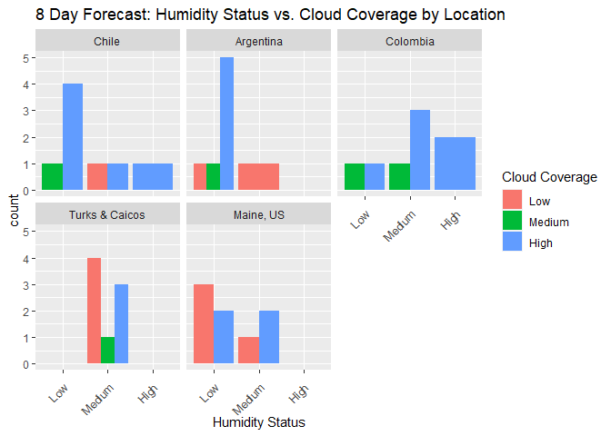

```r
sum.tab <- weather %>% group_by(location, humidity.status, cloud.coverage) %>% summarise(count = n())

g6 <- ggplot(sum.tab, aes(x = humidity.status, y = count))

g6 + geom_bar(aes(fill = cloud.coverage), stat = "identity", position = "dodge") + facet_wrap(~ location) + labs(title = "8 Day Forecast: Humidity Status vs. Cloud Coverage by Location", x = "Humidity Status") + scale_fill_discrete(name = "Cloud Coverage") + theme(axis.text.x = element_text(angle = 45, vjust = .8, hjust = 1))
```

Next, I’ll look at how location affects minimum and maximum daily temperature using boxplots.

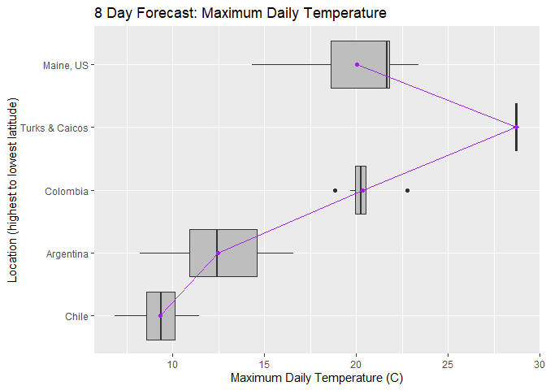

```r
max.means <- weather %>% group_by(location) %>% summarise(average = mean(maxtemp))

g <- ggplot(weather, aes(x = location, y = maxtemp))

g + geom_boxplot(fill = "grey") + geom_point(max.means, mapping = aes(x = location, y = average), color = "purple") + geom_line(max.means, mapping = aes(x = location, y = average, group = 1), color = "purple") + labs(title = "8 Day Forecast: Maximum Daily Temperature",x = "Location (highest to lowest latitude)", y = "Maximum Daily Temperature (C)") + coord_flip()
```

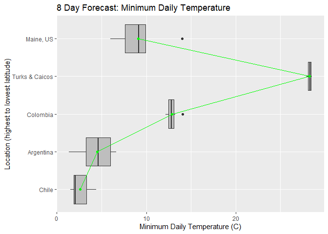

```r
min.means <- weather %>% group_by(location) %>% summarise(average = mean(mintemp))

g1 <- ggplot(weather, aes(x = location, y = mintemp))

g1 + geom_boxplot(fill = "grey") + geom_point(min.means, mapping = aes(x = location, y = average), color = "green") + geom_line(min.means, mapping = aes(x = location, y = average, group = 1), color = "green") + labs(title = "8 Day Forecast: Minimum Daily Temperature", x = "Location (highest to lowest latitude)", y = "Minimum Daily Temperature (C)") + coord_flip()
```

Both boxplots are fairly consistent with each other, showing Turks and Caicos as having the highest minimum and maximum temperature, and locations at the highest and lowest latitudes as having the lowest minimum and maximum temperatures. Although Cucata, Colombia is closer to the equator than Turks and Caicos Islands, a possible reason as to why it may not be warmer is its elevation at 320 meters (1,050 ft).

Now we’ll turn to exploring `humidity` as a quantitative variable, creating a histogram with density plots of `humidity` facetted by `location`. We’ll also create a boxplot of the same information.

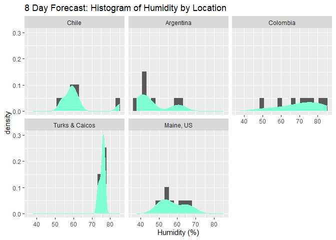

```r
g2 <- ggplot(weather, aes(x = humidity))

g2 + geom_histogram(bins = 20, aes(y = ..density..)) + geom_density(color = "aquamarine", fill = "aquamarine") + facet_wrap(~location) + labs(title = "8 Day Forecast: Histogram of Humidity by Location", x = "Humidity (%)")
```

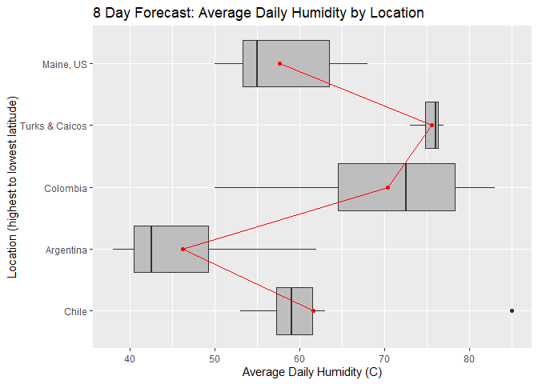

```r
hum.means <- weather %>% group_by(location) %>% summarise(average = mean(humidity))

g3 <- ggplot(weather, aes(x = location, y = humidity))

g3 + geom_boxplot(fill = "grey") + geom_point(hum.means, mapping = aes(x = location, y = average), color = "red") + geom_line(hum.means, mapping = aes(x = location, y = average, group = 1), color = "red") + labs(title = "8 Day Forecast: Average Daily Humidity by Location", x = "Location (highest to lowest latitude)", y = "Average Daily Humidity (C)") + coord_flip()
```

This histogram and boxplot are very helpful in displaying how humidity varies by location. While Argentina and Maine consistently show lower humidity levels, Turks and Caicos is vary consistent in showing high humidity, while Colombia and Chile’s humidities are less consistent.

To prepare for the next plot, I’ll convert all variables with timestamps to numeric variables of time since 00:00:00, calculated in minutes.

```r
weather$Sunrise <- round(60 * 24 * as.numeric(times(weather$Sunrise)),digits = 2)

weather$Sunset <- round(60 * 24 * as.numeric(times(weather$Sunset)),digits = 2)

weather$Moonrise <- round(60 * 24 * as.numeric(times(weather$Moonrise)), digits = 2)

weather$Moonset <- round(60 * 24 * as.numeric(times(weather$Moonset)), digits = 2)

weather
```

```
##          location Year Month Day Sunrise  Sunset Moonrise
## 1       Maine, US 2021    10   5  400.48 1091.70      322
## 2       Maine, US 2021    10   6  401.68 1089.88      398
## 3       Maine, US 2021    10   7  402.88 1088.08      476
## 4       Maine, US 2021    10   8  404.10 1086.30      555
## 5       Maine, US 2021    10   9  405.32 1084.52      636
## 6       Maine, US 2021    10  10  406.53 1082.75      716
## 7       Maine, US 2021    10  11  407.77 1081.00      789
## 8       Maine, US 2021    10  12  409.00 1079.25      852
## 9  Turks & Caicos 2021    10   5  396.58 1108.48      341
## 10 Turks & Caicos 2021    10   6  396.87 1107.57      400
## 11 Turks & Caicos 2021    10   7  397.18 1106.67      462
## 12 Turks & Caicos 2021    10   8  397.48 1105.78      525
## 13 Turks & Caicos 2021    10   9  397.80 1104.92      591
## 14 Turks & Caicos 2021    10  10  398.13 1104.03      658
```

[output cut: 149 more lines]

The scatterplot below allows us to look at how sunrise time changes over the course of 8 days in each location.

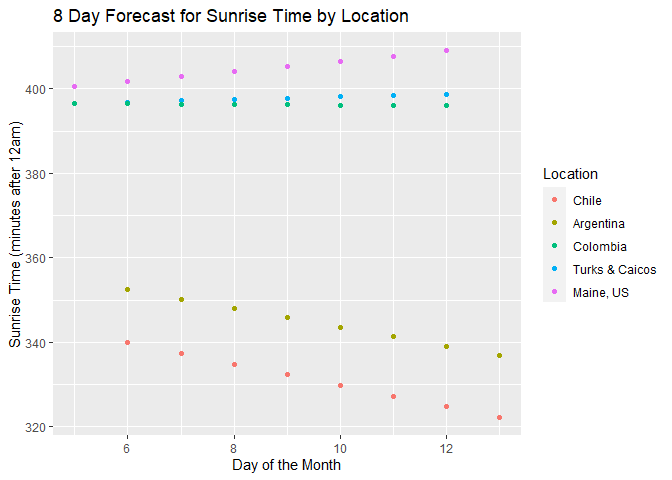

```r
g4 <- ggplot(weather, aes(x = Day, y = Sunrise))

g4 + geom_point(aes(color = location)) + scale_color_discrete(name = "Location") + labs(title = "8 Day Forecast for Sunrise Time by Location", x = "Day of the Month", y = "Sunrise Time (minutes after 12am)")
```

I think this plot is especially cool to look at, since one can clearly distinguish which locations are in the southern hemisphere, and which are in the northern hemisphere. While the sun is rising increasingly later in the northern hemisphere, it’s rising increasingly earlier in the southern hemisphere.

Lastly, we’ll explore the relationship between maximum daily temperature and daily pressure in the scatterplot below.

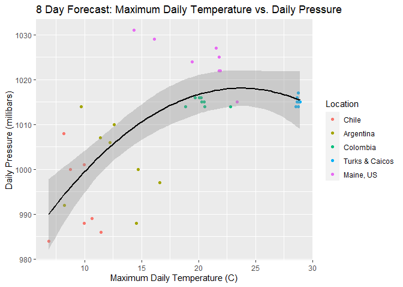

```r
g5 <- ggplot(weather, aes(x = maxtemp, y = pressure))

g5 + geom_point(aes(color = location)) + geom_smooth(method = lm, formula = y~poly(x,2), color = "black") + scale_color_discrete(name = "Location") + labs(title = "8 Day Forecast: Maximum Daily Temperature vs. Daily Pressure", x = "Maximum Daily Temperature (C)", y = "Daily Pressure (millibars)")
```

There seems to be a medium-strength, positive relationship between temperature and pressure. However, the data from the Turks and Caicos Islands appears to deviate slightly from the general trend, which is why I decided to fit a quadratic model. To fit a more accurate model, we may need to pull data from more locations from the API.

## Final Thoughts

Extracting data from an API follows a generally simple process, although different APIs have varying syntax for how to assemble the URL. Hopefully, this vignette was helpful in exemplifying how to access a typical API, clean the data, and perform a few basic analyses.

To read my blog post about this project, visit http://atbiggie.github.io.